# Milestone 1

## Project Idea

In the competitive world of e-commerce, customer satisfaction and engagement are critical for long-term success. Understanding customer behavior and feedback provides companies with actionable insights to improve products, services, and customer relationships. Our project focuses on analyzing customer reviews and associated behaviors to uncover patterns and trends that can aid decision-making.

## The Business Problem

Companies often receive large volumes of customer reviews, ratings, and purchase data, but they fail to utilize these effectively to understand customer sentiment or identify trends. Reviews can provide valuable insights into product performance, customer satisfaction, and areas of improvement. By analyzing these reviews, businesses can enhance their product offerings, identify potential pain points, and address customer needs effectively.

## Objective

The objective of this project is to analyze customer review data to uncover patterns, trends, and actionable insights. Specifically, we aim to:

- Identify common themes in customer feedback.
- Explore trends in customer behavior over time.
- Understand correlations between numerical ratings, textual feedback, and review engagement metrics.

The ultimate goal is to equip businesses with the insights needed to make informed decisions about product improvement, customer engagement strategies, and marketing campaigns.

## Specific Model Objective

Our model will be designed to predict the sentiment of a customer review based on textual feedback and review engagement metrics.

Model Type: Classification Model Target Variable: Score (1-5 star rating)

### Predictors (Features):

- Review Text (TF-IDF Features, Sentiment Score, Word Count)
- Helpfulness Metrics (Numerator, Denominator, Helpfulness Ratio)
- Temporal Features (Year, Month)

## Dataset Description

The dataset Amazon Product Reviews comprises customer reviews, ratings, and review metadata from Kaggle. It includes:

| Feature | Description |
| --- | --- |
| Review Text | Detailed feedback provided by customers. |
| Ratings | Numerical scores assigned to products (e.g., 1–5). |
| Helpfulness Metrics | Counts of how many users found a review helpful or unhelpful. |
| Timestamp | When the review was submitted. |

This data allows us to perform a deep dive into customer feedback and assess patterns over time and across products.

# EDA

## Bar Chart: Distribution of Ratings

|  | Id | ProductId | UserId | ProfileName | HelpfulnessNumerator | HelpfulnessDenominator | Score | Time | Summary | Text |
| --- | --- | --- | --- | --- | --- | --- | --- | --- | --- | --- |
| 0 | 1 | B001E4KFG0 | A3SGXH7AUHU8GW | delmartian | 1 | 1 | 5 | 1303862400 | Good Quality Dog Food | I have bought several of the Vitality canned d... |
| 1 | 2 | B00813GRG4 | A1D87F6ZCVE5NK | dll pa | 0 | 0 | 1 | 1346976000 | Not as Advertised | Product arrived labeled as Jumbo Salted Peanut... |
| 2 | 3 | B000LQOCH0 | ABXLMWJIXXAIN | Natalia Corres "Natalia Corres" | 1 | 1 | 4 | 1219017600 | "Delight" says it all | This is a confection that has been around a fe... |
| 3 | 4 | B000UA0QIQ | A395BORC6FGVXV | Karl | 3 | 3 | 2 | 1307923200 | Cough Medicine | If you are looking for the secret ingredient i... |
| 4 | 5 | B006K2ZZ7K | A1UQRSCLF8GW1T | Michael D. Bigham "M. Wassir" | 0 | 0 | 5 | 1350777600 | Great taffy | Great taffy at a great price. There was a wid... |

```
<class 'pandas.core.frame.DataFrame'>
RangeIndex: 568454 entries, 0 to 568453
Data columns (total 10 columns):
 #   Column                  Non-Null Count   Dtype
---  ------                  --------------   -----
 0   Id                      568454 non-null  int64
 1   ProductId               568454 non-null  object
 2   UserId                  568454 non-null  object
 3   ProfileName             568428 non-null  object
 4   HelpfulnessNumerator    568454 non-null  int64
 5   HelpfulnessDenominator  568454 non-null  int64
 6   Score                   568454 non-null  int64
 7   Time                    568454 non-null  int64
 8   Summary                 568427 non-null  object
 9   Text                    568454 non-null  object
dtypes: int64(5), object(5)
memory usage: 43.4+ MB
```

```
Id                         0
ProductId                  0
UserId                     0
ProfileName               26
HelpfulnessNumerator       0
HelpfulnessDenominator     0
Score                      0
Time                       0
Summary                   27
Text                       0
dtype: int64
```

|  | Id | HelpfulnessNumerator | HelpfulnessDenominator | Score | Time |
| --- | --- | --- | --- | --- | --- |
| count | 568454.000000 | 568454.000000 | 568454.00000 | 568454.000000 | 5.684540e+05 |
| mean | 284227.500000 | 1.743817 | 2.22881 | 4.183199 | 1.296257e+09 |
| std | 164098.679298 | 7.636513 | 8.28974 | 1.310436 | 4.804331e+07 |
| min | 1.000000 | 0.000000 | 0.00000 | 1.000000 | 9.393408e+08 |
| 25% | 142114.250000 | 0.000000 | 0.00000 | 4.000000 | 1.271290e+09 |
| 50% | 284227.500000 | 0.000000 | 1.00000 | 5.000000 | 1.311120e+09 |
| 75% | 426340.750000 | 2.000000 | 2.00000 | 5.000000 | 1.332720e+09 |
| max | 568454.000000 | 866.000000 | 923.00000 | 5.000000 | 1.351210e+09 |

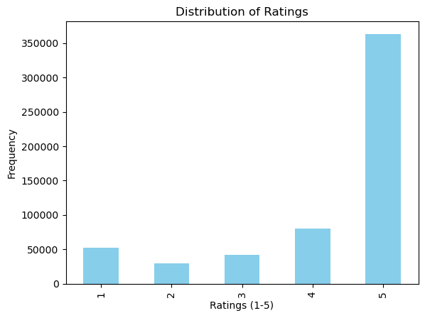

The distribution of ratings shows a strong skew toward higher ratings, particularly 5 stars, which dominate the dataset. There are fewer 1- and 2-star ratings, indicating that most customers are satisfied with the products. The presence of lower ratings (1 and 2 stars) still highlights areas of potential concern and improvement for specific products. This also shows a significant data imbalance we will need to address.

## Word Cloud: Common Words in Reviews

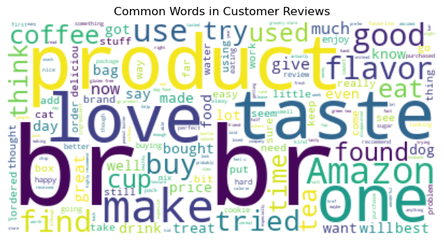

## Box Plot: Helpfulness Metrics by Rating

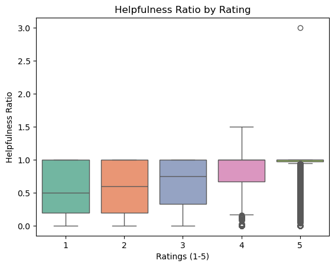

Higher-rated reviews (4 and 5 stars) tend to have a higher helpfulness ratio compared to lower-rated reviews (1 and 2 stars). Lower-rated reviews exhibit a broader range of helpfulness ratios, with some being rated highly helpful and others not helpful at all. Outliers in the helpfulness ratio indicate cases where reviews have been disproportionately marked as helpful or unhelpful.

## Time Series Plot: Number of Reviews Over Time

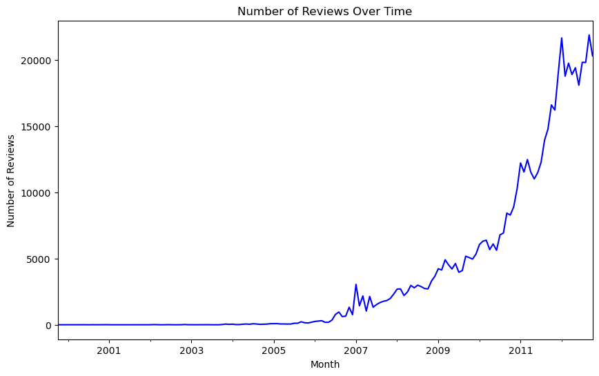

The number of reviews has significantly increased over time, with a sharp rise observed after 2008. This trend could be attributed to factors like increased e-commerce adoption, product popularity, or improved review systems.

# Milestone 2

## Drop any features that are not useful for your model building and explain why they are not useful.

Dropped the following columns:

- Id – A unique identifier for each row, which in our analysis, does not contribute to predicting review sentiment.
- UserId & ProfileName – User information is not relevant for predicting ratings.
- ProductId – It could be useful for product-level analysis, but it's not helping in general sentiment prediction.

Removing unnecessary columns reduces model complexity and improves performance.

## Transform features if necessary.

Converted Time into Year and Month this allows us to analyze trends over time (e.g., do customers rate products differently in different years?). Helps the model capture seasonality effects (e.g., holiday seasons might have different sentiment patterns).

|  | HelpfulnessNumerator | HelpfulnessDenominator | Score | Summary | Text | HelpfulnessRatio | Month | Year |
| --- | --- | --- | --- | --- | --- | --- | --- | --- |
| 0 | 1 | 1 | 5 | Good Quality Dog Food | I have bought several of the Vitality canned d... | 1.0 | 4 | 2011 |
| 1 | 0 | 0 | 1 | Not as Advertised | Product arrived labeled as Jumbo Salted Peanut... | NaN | 9 | 2012 |
| 2 | 1 | 1 | 4 | "Delight" says it all | This is a confection that has been around a fe... | 1.0 | 8 | 2008 |
| 3 | 3 | 3 | 2 | Cough Medicine | If you are looking for the secret ingredient i... | 1.0 | 6 | 2011 |
| 4 | 0 | 0 | 5 | Great taffy | Great taffy at a great price. There was a wid... | NaN | 10 | 2012 |

We computed HelpfulnessRatio = HelpfulnessNumerator / HelpfulnessDenominator, replacing NaN values with 0. This helps quantify how trustworthy a review is. Reviews with higher helpfulness scores may be more influential in predicting overall sentiment.

I am thinking short vs. long reviews may indicate differences in customer sentiment where detailed reviews might be more positive or more negative. Thi may help the model differentiate between informative and short responses.

We wnat to capture positive or negative tone of the review, using TextBlob to compute Text_Sentiment. this can help distinguish sarcastic reviews vs. genuinely positive/negative ones.

and we used TF-IDF (Term Frequency-Inverse Document Frequency) to transform Text into numerical features. Since Machine learning models cannot work with raw text. The TF-IDF gives more importance to important words, while reducing the weight of common words like "the" or "and".

Some months might see higher or lower ratings (e.g., during holidays or major sales events). this helps the model capture seasonal trends in customer sentiment.

|  | Score | HelpfulnessRatio | Year | Text_WordCount | Text_CharCount | Text_Sentiment | 10 | 100 | 12 | 15 | ... | Month_3 | Month_4 | Month_5 | Month_6 | Month_7 | Month_8 | Month_9 | Month_10 | Month_11 | Month_12 |
| --- | --- | --- | --- | --- | --- | --- | --- | --- | --- | --- | --- | --- | --- | --- | --- | --- | --- | --- | --- | --- | --- |
| 0 | 5 | 1.0 | 2011 | 48 | 263 | 0.450000 | 0.0 | 0.0 | 0.0 | 0.0 | ... | False | True | False | False | False | False | False | False | False | False |
| 1 | 1 | 0.0 | 2012 | 31 | 190 | -0.033333 | 0.0 | 0.0 | 0.0 | 0.0 | ... | False | False | False | False | False | False | True | False | False | False |
| 2 | 4 | 1.0 | 2008 | 94 | 509 | 0.133571 | 0.0 | 0.0 | 0.0 | 0.0 | ... | False | False | False | False | False | True | False | False | False | False |
| 3 | 2 | 1.0 | 2011 | 41 | 219 | 0.166667 | 0.0 | 0.0 | 0.0 | 0.0 | ... | False | False | False | True | False | False | False | False | False | False |
| 4 | 5 | 0.0 | 2012 | 27 | 140 | 0.483333 | 0.0 | 0.0 | 0.0 | 0.0 | ... | False | False | False | False | False | False | False | True | False | False |

5 rows × 517 columns

## Featrue Importance

|  | Score | HelpfulnessRatio | Year | Text_WordCount | Text_CharCount | Text_Sentiment | 10 | 100 | 12 | 15 | ... | Month_3 | Month_4 | Month_5 | Month_6 | Month_7 | Month_8 | Month_9 | Month_10 | Month_11 | Month_12 |
| --- | --- | --- | --- | --- | --- | --- | --- | --- | --- | --- | --- | --- | --- | --- | --- | --- | --- | --- | --- | --- | --- |
| 0 | 5 | 1.0 | 2011 | 48 | 263 | 0.450000 | 0.0 | 0.0 | 0.0 | 0.0 | ... | False | True | False | False | False | False | False | False | False | False |
| 1 | 1 | 0.0 | 2012 | 31 | 190 | -0.033333 | 0.0 | 0.0 | 0.0 | 0.0 | ... | False | False | False | False | False | False | True | False | False | False |
| 2 | 4 | 1.0 | 2008 | 94 | 509 | 0.133571 | 0.0 | 0.0 | 0.0 | 0.0 | ... | False | False | False | False | False | True | False | False | False | False |
| 3 | 2 | 1.0 | 2011 | 41 | 219 | 0.166667 | 0.0 | 0.0 | 0.0 | 0.0 | ... | False | False | False | True | False | False | False | False | False | False |
| 4 | 5 | 0.0 | 2012 | 27 | 140 | 0.483333 | 0.0 | 0.0 | 0.0 | 0.0 | ... | False | False | False | False | False | False | False | True | False | False |

5 rows × 517 columns

Spliting the data and prevent data leakage, and ensuring the model generalizes well to unseen reviews. and fo use to evaluate performance on a separate test set.

### Feature Importance with Tree-Based Models

```
Counter({1: 290220, 5: 290220, 4: 290220, 3: 290220, 2: 290220})
```

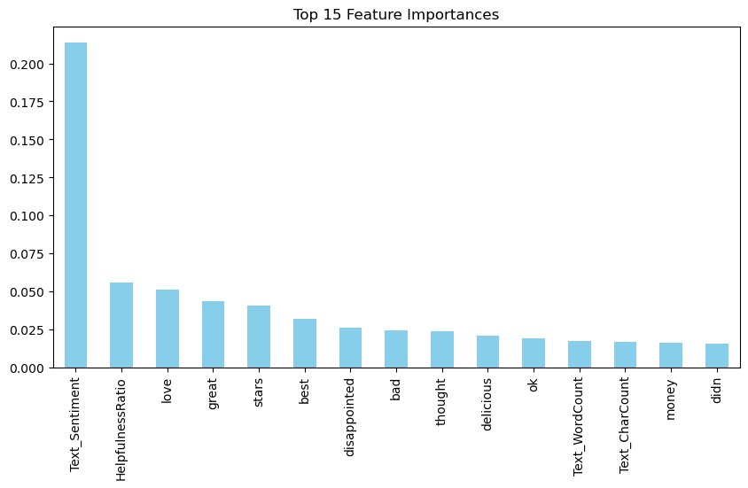

### Mutual Information

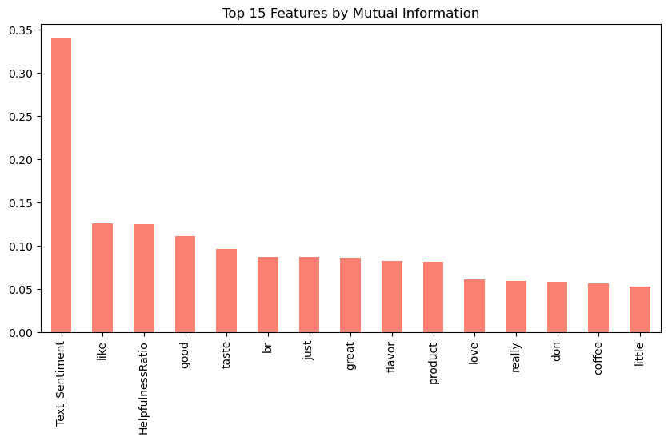

#### Top Features:

Text_Sentiment is the most important feature in both models. This makes sense because sentiment polarity directly reflects the review's positivity or negativity.

HelpfulnessRatio, reviews marked as "helpful" by users seem to impact the rating. This suggests that highly helpful reviews may provide more valuable sentiment.

Words in TF-IDF like " "love," "great," "good," "stars," "best" are among the most important. It makes sense, as these words likely indicate strong sentiment.

Both Mutual Information and Random Forest confirm that Text_Sentiment and HelpfulnessRatio are the strongest predictors of review ratings, highlighting the importance of sentiment analysis and user engagement. MI emphasizes frequent positive words, like, good, and great, whereas RF captures both positive and negative sentiment, love, disappointed, or bad, making it more effective at identifying contrasting opinions. Stopwords (br, don) appear in MI rankings, suggesting a need for cleanup. Text length features, word count and char count are not significant, indicating that review content matters more than its length.

```
 Random Forest (Top MI + RF Features) Performance:

              precision    recall  f1-score   support

           1       0.61      0.70      0.65     10326
           2       0.59      0.45      0.51      5855
           3       0.63      0.46      0.54      8485
           4       0.63      0.50      0.56     16123
           5       0.84      0.91      0.87     72902

    accuracy                           0.77    113691
   macro avg       0.66      0.60      0.63    113691
weighted avg       0.76      0.77      0.76    113691
```

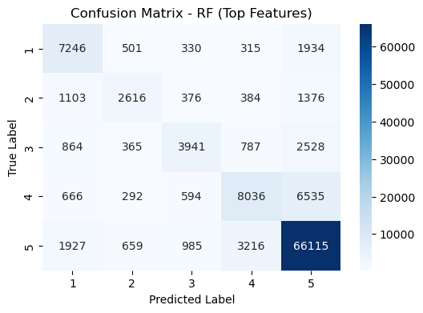

```
ROC-AUC Score: 0.8920
============================================================
```

The evaluation of our Random Forest model trained on SMOTE-balanced data with top MI and RF features shows strong overall performance (77% accuracy, 0.89 ROC-AUC), but mid-range ratings (2, 3, 4 stars) are frequently misclassified, while 5-star reviews dominate predictions. Recall for lower ratings is lower (45-50%), meaning these reviews are often confused with neighboring classes. The confusion matrix confirms this trend, with many 3-star and 4-star reviews classified as 5-star.

Every step in **Milestone 2** was chosen to:

- Improve data quality by handling missing values.
- Enhance feature representation whith sentiment, TF-IDF, helpfulness score.
- and prepare data for machine learning with the train-test split.

# Milestone 3

### Model Selection

Since our target variable is categorical (1-5 star ratings), a classification problem; and given the dataset size and feature types, I think the following models are worth considering:

- Logistic Regression: Simple baseline model to establish performance.
- Random Forest: Tree-based model that handles non-linearity and feature interactions well.
- Gradient Boosting: Optimized tree-based model for better accuracy.

```
Training RandomForest...
ROC-AUC Score: 0.8870
Precision-Recall AUC Score: 0.8318

RandomForest Model Performance:
              precision    recall  f1-score   support

           1       0.61      0.70      0.65     10326
           2       0.57      0.45      0.50      5855
           3       0.61      0.47      0.53      8485
           4       0.62      0.50      0.55     16123
           5       0.84      0.90      0.87     72902

    accuracy                           0.77    113691
   macro avg       0.65      0.60      0.62    113691
weighted avg       0.76      0.77      0.76    113691
```

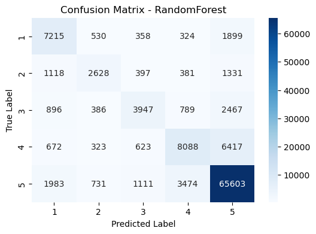

```
============================================================
Training LogisticRegression...
ROC-AUC Score: 0.7318
Precision-Recall AUC Score: 0.6239

LogisticRegression Model Performance:
              precision    recall  f1-score   support

           1       0.30      0.59      0.40     10326
           2       0.15      0.23      0.18      5855
           3       0.18      0.22      0.20      8485
           4       0.24      0.33      0.27     16123
           5       0.83      0.59      0.69     72902

    accuracy                           0.51    113691
   macro avg       0.34      0.39      0.35    113691
weighted avg       0.61      0.51      0.54    113691
```

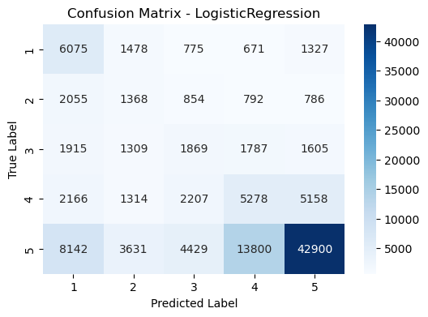

```
============================================================
Training XGBoost...
ROC-AUC Score: 0.7715
Precision-Recall AUC Score: 0.6571

XGBoost Model Performance:
              precision    recall  f1-score   support

           1       0.40      0.61      0.48     10326
           2       0.22      0.23      0.23      5855
           3       0.28      0.20      0.23      8485
           4       0.32      0.24      0.27     16123
           5       0.79      0.79      0.79     72902

    accuracy                           0.63    113691
   macro avg       0.40      0.42      0.40    113691
weighted avg       0.62      0.63      0.62    113691
```

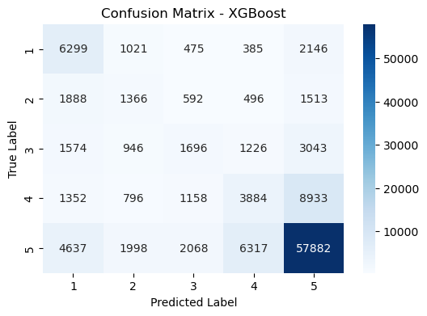